# Separating the Anthropogenic Signal from Solar-Locked Natural Variability in Global Ocean SST Anomalies, 1854–2026

A Singular-Spectrum and Growth-Curve Decomposition, with a Mean-Cycle Control

Author

Affiliation

Alf Loeffler

Independent researcher

Published

September 12, 2026

Keywords

sea surface temperature, singular spectrum analysis, ESPRIT, solar cycle, anthropogenic warming, Richards growth curve

## Abstract

Attribution of long-term ocean warming requires that the secular anthropogenic component be separated from natural variability whose dominant periods — solar, bidecadal and interannual — are comparable in amplitude to the forced trend over multi-decadal windows. Here we decompose an area-weighted global ocean sea surface temperature (SST) anomaly record of 2068 monthly values (1854.00–2026.25) into (i) a *solar-locked* component, obtained by anchoring a cubic spline to the minima of a sunspot-derived solar-power proxy, (ii) an oscillatory field characterised by Singular Spectrum Analysis (SSA) with ESPRIT parameter estimation, and (iii) a secular industrial component defined as the residual against a Generalized Additive Model (GAM) baseline trained on the pre-1938 record and extrapolated forward.

ESPRIT identifies three regimes in the detrended field, listed in Table 2. The analysis is repeated with the spline knots placed at the **mean** sunspot-cycle interval of 10.89 yr (standard deviation 0.84 yr over 15 cycles) rather than at the observed solar minima. This mean-cycle control serves two purposes: it bounds how much of the recovered solar band is imposed by the knot placement itself, and the spread between the two constructions provides an empirical uncertainty scale for the estimated periods in the absence of a formal confidence interval.

The industrial residual is near zero before the Second World War and accelerates after 1950. A four-parameter symmetric logistic fit places the inflection at 1984.6 yr. Releasing the symmetry constraint through a Richards growth curve, with the rate coefficient $B$ held at the value obtained from the logistic fit, yields a location parameter $t_0 = 1977.9$ yr with shape $\nu = 0.587$. Because $t_0$ is a location parameter and not the inflection when $\nu \ne 1$, the date of maximum acceleration is $t_0 - \ln\nu/B = 1982.4$ yr (95% interval 1981.52 - 1983.74, model-conditional), a shift of -2.2 yr relative to the symmetric fit.

## Plain Language Summary

The ocean surface has warmed since the nineteenth century, but the warming has not been steady. Natural rhythms — most of them tied to the roughly eleven-year and twenty-year solar cycles and to the Pacific — push ocean temperature up and down by a few tenths of a degree over decades, and these swings sit on top of the warming caused by industrial emissions. This study separates the two. We first build a curve that follows the natural solar rhythm, then use signal-processing methods to measure the length and stability of each natural cycle, and finally estimate what the ocean would have done without industrial influence by projecting forward a statistical model fitted only to data before 1938. The difference between the observed record and that projection is our estimate of the industrial effect. To check that the solar rhythms we find are really in the ocean data and not merely a consequence of how we built the curve, the whole analysis is repeated with the curve tied to a regular, average-length solar cycle instead of the observed one. The result suggests that a natural cold phase around the turn of the century partly hid the human-caused warming of the late twentieth century, so the underlying forced trend over that period was steeper than the raw record suggests. How much steeper depends on assumptions in the projection, which we state and test.

# 1 Introduction

## 1.1 Motivation

Global ocean heat content is the principal reservoir of the planetary energy imbalance, and SST is its most densely observed expression. Because roughly ninety per cent of the incoming solar energy retained by the climate system is stored in the ocean, the ocean surface record carries both the secular signature of anthropogenic forcing and the imprint of natural variability in the incident and absorbed solar flux. Separating the two is the classical attribution problem in its most direct form.

The difficulty is one of timescale overlap rather than of amplitude. Over a window of two to three decades, the amplitude of multi-decadal natural variability in SST is of the same order as the accumulated forced trend. Trends estimated over such windows therefore inherit the phase of the natural cycles at their endpoints, which is the mechanism behind the widely discussed moderation of surface warming in the 1998–2013 period (Kosaka and Xie 2013; Medhaug et al. 2017).

## 1.2 Previous approaches

Two families of method dominate. The first removes known modes of variability by multiple regression on indices of the El Niño–Southern Oscillation, volcanic aerosol loading and total solar irradiance, and interprets the residual as the forced signal (Foster and Rahmstorf 2011). This is transparent but presupposes that each index is an adequate and mutually independent predictor, and that the response is instantaneous and linear. The second family is data-adaptive: Singular Spectrum Analysis and related subspace techniques extract oscillatory components from the record itself without prescribing their form (Golyandina et al. 2001; Golyandina and Korobeynikov 2014), at the cost of requiring a separate criterion to decide which reconstructed components constitute “trend” and which “variability”.

## 1.3 Aim and structure of this study

This study combines a physically anchored construction of the natural component with a data-adaptive characterisation of it. Specifically we ask:

1. Can a trend anchored to the phase of the solar power variation (the *solar-locked trend*) isolate the harmonic content of the SST record more cleanly than a purely statistical smoother?
2. What are the periods, damping rates and stationarity of the resulting oscillatory modes, estimated objectively rather than assumed — and how much of that structure is imposed by the anchoring itself?
3. If the pre-1938 record is taken as an approximation of the pre-industrial state, what secular component does the later record require, and what functional form does it take?
4. How do the isolated natural and industrial components interfere, and what does that interference imply for trends estimated over short windows?

Section 2 describes the data, Section 3 the methods, Section 4 the step-by-step results, and Section 5 the interpretation and the limitations that bound it.

# 2 Data

## 2.1 Sea surface temperature anomalies

Monthly SST fields are taken from the NOAA Extended Reconstructed Sea Surface Temperature, version 5 (ERSSTv5; `sst.mnmean`), as distributed by NOAA PSL (Huang et al. 2017). The land–ocean classification and the ocean fraction of each grid cell are taken from the Berkeley Earth land/ocean product (Rohde and Hausfather 2020); grid cells with a land fraction above 10 per cent are excluded.

A global mean is formed as a double-weighted average: each cell is weighted by its ocean fraction and by its area relative to an equatorial cell, so that the result is an area-true ocean-only mean rather than a grid-cell mean. Both the weighted mean and the weighted median were computed; the mean is used throughout, with the median retained as a robustness check against localised outliers.

ERSSTv5 begins in January 1854. The working file assembled for this project extends back to 1850.00, but no documented source could be established for the segment preceding 1854. That segment is therefore **discarded**: all results below are computed on 2068 monthly values covering 1854.00–2026.25, with 48 leading months removed relative to the working file.

## 2.2 Solar proxy

Daily international sunspot numbers (version 2.0) are obtained from WDC-SILSO, Royal Observatory of Belgium, and aggregated to monthly means. Solar power, used here as a proxy for the variable component of total solar irradiance, is taken as a quadratic function of sunspot number, and only the anomaly about its long-term mean is retained.

## 2.3 Pre-processing

The annual and semi-annual cycles — the latter dominant at the equator — are removed from the anomaly series using the classical seasonal-means estimator of the `itsmr` package with harmonics at 12 and 6 months. All subsequent analysis operates on this deseasonalised series.

# 3 Methods

## 3.1 Construction of the solar-locked trend

The variable solar power passes through a minimum once per Schwabe cycle. The times of these minima define a set of knots that is fixed by solar phase alone and is not derived from the SST record. A cubic B-spline basis with knots at those times is regressed on the deseasonalised SST anomaly, giving the *solar-locked trend*: a curve free to follow the ocean record, but whose flexibility is licensed only at solar-phase transitions.

This construction is the methodological core of the study. It differs from a conventional smoother in that its degrees of freedom are placed by an external physical clock rather than by a bandwidth criterion.

## 3.2 The mean-cycle control

Anchoring knots to solar minima and then reporting solar periodicities in the residual field is open to the objection that the periodicity is partly imposed by the construction. To bound that effect, the entire trend construction is repeated with the knots placed at a **constant** interval equal to the mean observed cycle length,

$$\bar{T} = \frac{1}{n}\sum_{i=1}^{n}\bigl(\tau_{i+1}-\tau_i\bigr) = 10.89\ \text{yr},$$

where $\tau_i$ are the observed solar minima, starting from the first observed minimum and using the same number of knots. The mean-cycle series carries the same number of degrees of freedom and the same average spacing as the phase-locked series, but no information about the actual timing of individual cycles.

Two quantities are read from this control. First, any oscillatory structure that survives in the mean-cycle construction cannot have been imposed by phase-accurate knot placement. Second, the difference between the two constructions gives an empirical scale for the uncertainty of the estimated periods, which is otherwise not available: the spread between two defensible anchorings bounds the estimate more honestly than a nominal standard error computed under an independence assumption that the strongly autocorrelated residuals violate.

## 3.3 Separation of the non-harmonic component

Each locked trend still contains the periodic solar response. A LOESS fit of span 0.25 and degree 2 (Cleveland and Devlin 1988) extracts its slowly varying, non-harmonic part. The difference between the deseasonalised anomaly and that non-harmonic part gives the harmonic residual field on which the spectral analysis is performed.

## 3.4 Spectral characterisation: SSA and ESPRIT

Singular Spectrum Analysis embeds the residual series in a trajectory matrix of window length $L$ and decomposes it into eigentriples (Golyandina et al. 2001; Golyandina and Korobeynikov 2014). Components are grouped into pairs, since a damped sinusoid appears in SSA as a pair of eigenvectors in quadrature; paired scatter plots and the w-correlation matrix are used to verify separability.

For each grouped pair, ESPRIT (Roy and Kailath 1989) estimates the complex root $z = \vert z\vert e^{i 2\pi f}$, which yields simultaneously the oscillation frequency $f$ and the continuous growth or decay rate $\lambda = \ln\vert z\vert$. A modulus indistinguishable from unity indicates a stationary mode; $\vert z\vert < 1$ indicates decay over the observation window.

Two window lengths are used: $L = \lfloor N/2 \rfloor$ for the detrended residual field, which maximises resolution for long periods, and $L = 128$ for the decomposition of the solar-locked trend itself, which is the appropriate scale for separating its secular from its multi-decadal part.

## 3.5 Baseline extrapolation and the industrial residual

The record is split at the calendar year 1938, on the assumption that industrial emissions had no material effect on ocean SST before that date; the training set comprises 1008 months. A Generalized Additive Model with a **cyclic cubic spline basis** (`bs = "cc"`, $k = 30$; Wood 2017) is fitted to the training set only, then evaluated over the full record. The cyclic basis is a deliberate choice and not a default: it constrains the fitted function to match in value and first derivative at the two ends of the training window, so the continuation beyond 1938 repeats the pre-industrial pattern of variability rather than projecting its endpoint slope indefinitely. That is the appropriate constraint if the natural baseline is taken to be quasi-periodic, which is the hypothesis this study tests; it is the wrong constraint if the natural baseline carries a secular component of its own. Section 4.11 quantifies what the alternative would do to every downstream estimate. The industrial effect is defined as

$$\mathrm{industrial}(t) \;=\; \mathrm{anomaly}(t) \;-\; \widehat{\mathrm{GAM}}_{<1938}(t).$$

The split is now specified as a calendar year rather than as the midpoint of the record, so that it no longer moves when the record length changes; with the record truncated at 1854 the midpoint rule would have placed it near 1940.

## 3.6 Growth-curve models

The industrial residual is first fitted with a four-parameter symmetric logistic,

$$y(t) = b + \frac{L}{1 + e^{-k\,(t - t_0)}},$$

by Levenberg–Marquardt least squares, giving the rate coefficient $k$ and the inflection $t_0$. The symmetric logistic imposes equal curvature on the accelerating and saturating limbs, which has no physical justification for a system in which upper-ocean heat uptake, evaporation, cloud formation and albedo feedback operate on different timescales in the two phases.

The fit is therefore generalised to a Richards curve (Richards 1959),

$$y(t) = L + \frac{\Delta}{\bigl(1 + e^{-B\,(t - t_0)}\bigr)^{1/\nu}},$$

with $B$ held at the value returned by the logistic fit, so that the secular rate is not re-estimated and the two curves differ only in shape, and with $\nu$ free.

In this parametrisation $t_0$ is a **location parameter**, not the inflection point. Setting the second derivative to zero gives $e^{-B(t-t_0)} = \nu$, so the date of maximum acceleration is

$$t_{\mathrm{infl}} = t_0 - \frac{\ln \nu}{B},$$

which coincides with $t_0$ only when $\nu = 1$. All comparisons against the logistic are therefore made at $t_{\mathrm{infl}}$.

Holding $B$ fixed makes the joint optimisation of $(L, \Delta, t_0, \nu)$ ill-conditioned: near a poor starting point $L$ and $\Delta$ are close to collinear and the gradient matrix is singular. The coefficients are therefore obtained by profiling. For any $(\nu, t_0)$ the model is linear in $(L, \Delta)$, so a grid over $\nu \in [0.05, 10]$ (logarithmic, 60 nodes) and $t_0 \in [1930, 2020]$ (half-year steps) is evaluated with an exact linear least-squares solution at each node, and the best node is refined by Levenberg–Marquardt. The reported fit was obtained by profiled grid, refined by Levenberg-Marquardt. The logistic coefficients reported here come from the specification of the original analysis (started at 1988). The logistic fit uses starting values derived from the smoothed residual rather than fixed constants, with a ladder of fallbacks.

## 3.8 Software

All computation is performed in R. The analysis uses `Rssa` for SSA and ESPRIT, `mgcv` for the GAM, `minpack.lm` for Levenberg–Marquardt non-linear least squares, `itsmr` for seasonal adjustment and harmonic filtering, `splines` for the B-spline basis, and the `tidyverse` for data handling.

# 4 Results

## 4.1 The solar-locked trend and its non-harmonic component

The non-harmonic component of the phase-locked trend (Figure 1) has minima near 1912 and 1957 and a turning point near 1997, marked by the vertical lines. The mean-cycle control is overlaid: the two curves differ by an RMS of 0.002 °C, so the low-frequency shape of the trend is not an artefact of phase-accurate knot placement.

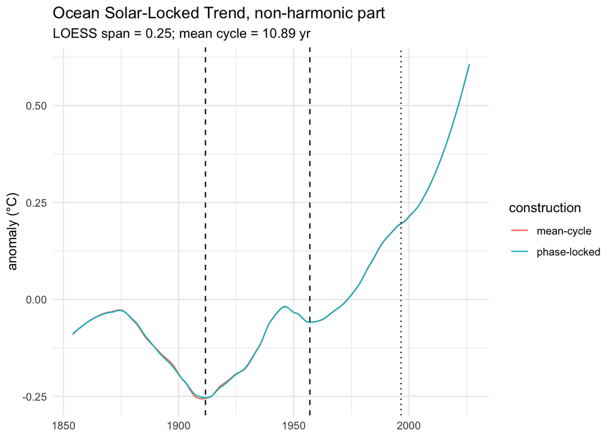

Figure 1: Non-harmonic component of the ocean solar-locked trend (LOESS, span 0.25), for knots at the observed solar minima (phase-locked) and at the mean cycle interval (control). Dashed lines mark the two minima; the dotted line marks the late turning point.

## 4.2 Sunspot cycle statistics

Table 1 summarises the knot intervals that define the two constructions.

Table 1: Intervals between successive solar-power minima over the analysis window, and the regular interval used for the mean-cycle control.

| Quantity | Value |
| --- | --- |
| Number of cycles spanned | 15.00 |
| Mean cycle length (yr) | 10.89 |
| Standard deviation (yr) | 0.84 |
| Shortest (yr) | 10.00 |
| Longest (yr) | 12.50 |
| Knots, phase-locked | 16.00 |
| Knots, mean-cycle control | 16.00 |

## 4.3 Total harmonic residual

Adding the periodic part back to the residuals recovers the total harmonic dependence of the global ocean anomaly (Figure 2).

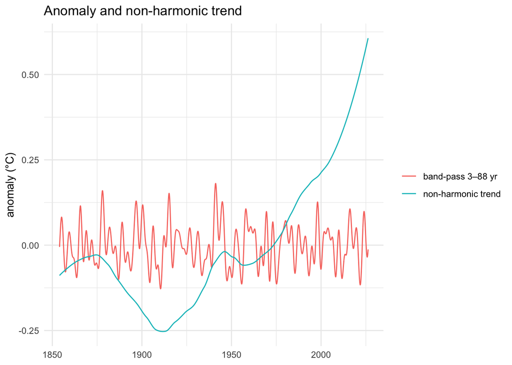

## 4.4 Low-pass structure of the residuals

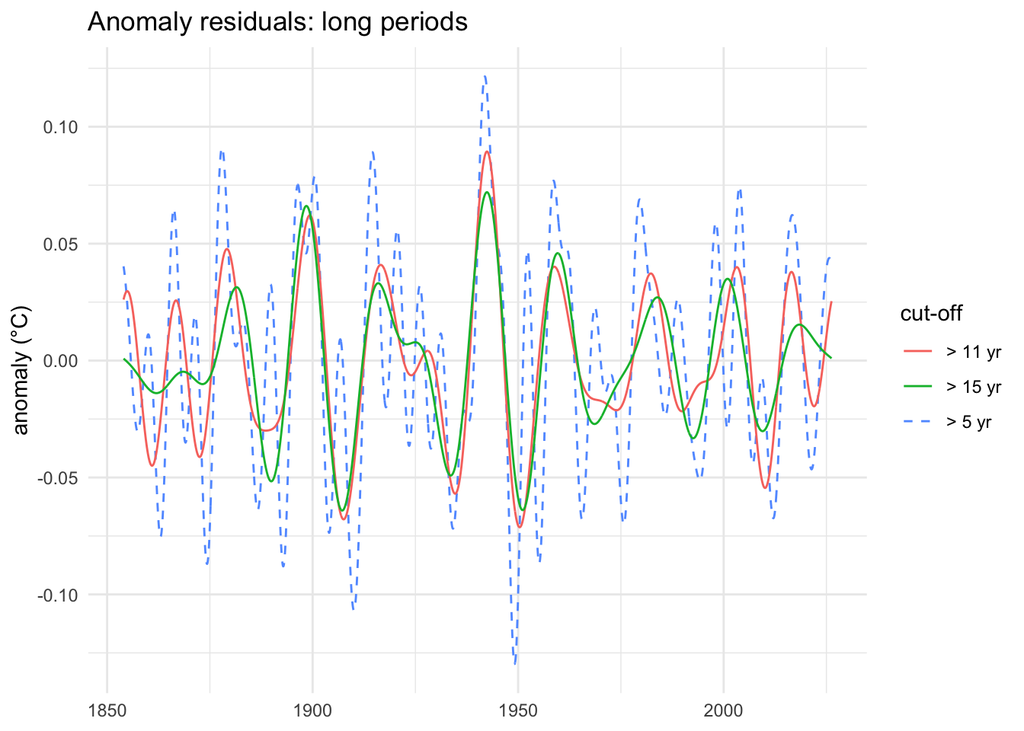

Figure 3: Anomaly residuals retained above cut-off periods of 5, 11 and 15 years (phase-locked construction).

## 4.5 Eigentriple structure of the detrended field

Paired scatter plots of the leading SSA eigenvectors (Figure 4) show the circular patterns that identify clean harmonic pairs.

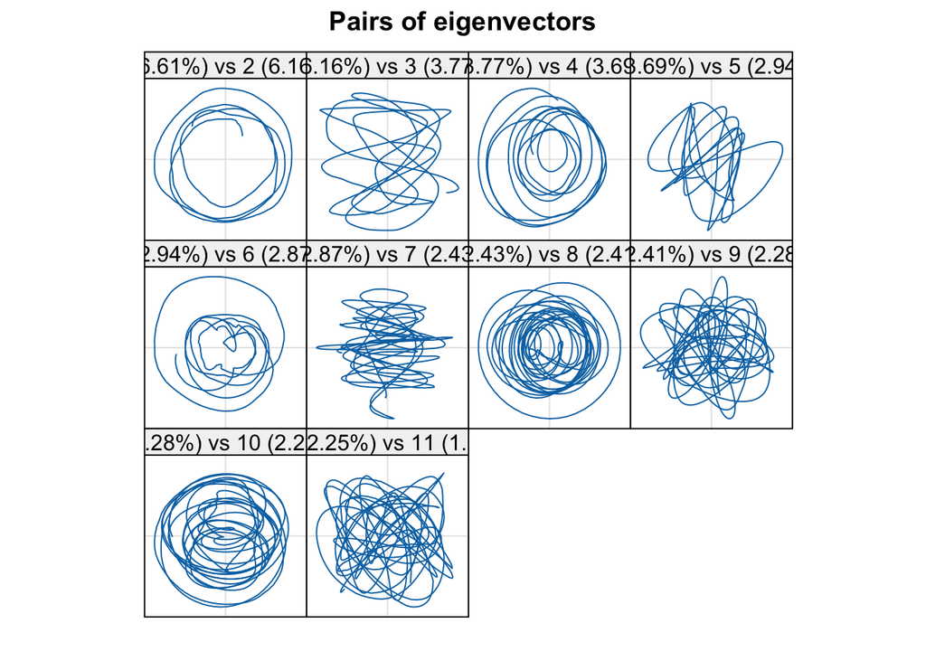

Figure 4: Paired eigenvector scatter plots of the detrended residual field, phase-locked construction. Circular trajectories indicate well-separated harmonic pairs.

## 4.6 ESPRIT parameter estimates and the mean-cycle control

Table 2 gives the period, damping rate and modulus of the five leading grouped pairs for the phase-locked construction, alongside the period recovered by the mean-cycle control.

Table 2: ESPRIT estimates for the five leading eigentriple pairs. T(phase) uses knots at the observed solar minima; T(mean) uses knots at the mean cycle interval. The last column is the difference between the two constructions and serves as an empirical uncertainty scale.

| Eigentriple pair | T phase-locked (yr) | T mean-cycle (yr) | Delta T (yr) | Modulus \|z\| | Rate lambda |
| --- | --- | --- | --- | --- | --- |
| 1,2 | 20.09 | 19.93 | 0.16 | 1.00020 | 0.00020 |
| 3,4 | 10.02 | 9.92 | 0.11 | 1.00054 | 0.00054 |
| 5,6 | 12.95 | 13.17 | -0.22 | 0.99935 | -0.00066 |
| 7,8 | 4.48 | 4.49 | -0.01 | 0.99959 | -0.00041 |
| 9,10 | 5.30 | 5.29 | 0.01 | 0.99874 | -0.00126 |

Three regimes emerge, and the group indices below are those of Table 2 rather than a separate numbering.

**Bidecadal / Hale magnetic mode — pair (1,2).** The leading pair isolates a low-frequency cycle at $T = 20.1$ yr with modulus $\vert z\vert = 1.00020$, stationary to within estimation error, consistent with solar-magnetic forcing on the ~22-year Hale cycle acting jointly with intrinsic bidecadal ocean variability. With only about 9 realisations in the record, the damping rate of this mode is weakly constrained and the near-unit modulus should not be read as a demonstration of exact stationarity.

**Split Schwabe solar band — pairs (3,4) and (5,6).** The eleven-year band resolves into twin sidebands at $T = 10.0$ yr and $T = 13.0$ yr. A doublet of this kind is the spectral signature of amplitude and phase modulation of a single carrier across the observation window rather than of two independent oscillators.

**Interannual recharge-oscillator band — pairs (7,8) and (9,10).** The higher-frequency pairs resolve $T = 4.5$ yr and $T = 5.3$ yr, within the characteristic bandwidth of the equatorial Pacific recharge oscillator (Jin 1997) and of interannual climate modes more generally. These are the pairs actually grouped in the code as `Pair_7_8` and `Pair_9_10`; earlier drafts of this analysis mislabelled them as pairs (4,5).

The mean-cycle control recovers the same band structure, with a maximum period difference of 0.22 yr across the five pairs (Table 2, column *Delta T*). The oscillatory content is therefore a property of the SST record and not an artefact of anchoring the spline to the observed solar minima; the phase-accurate anchoring sharpens the estimate but does not create the modes.

## 4.7 SSA decomposition of the solar-locked trend

Decomposing the phase-locked trend itself ($L = 128$) separates a secular component from multi-decadal and decadal oscillations (Figure 5).

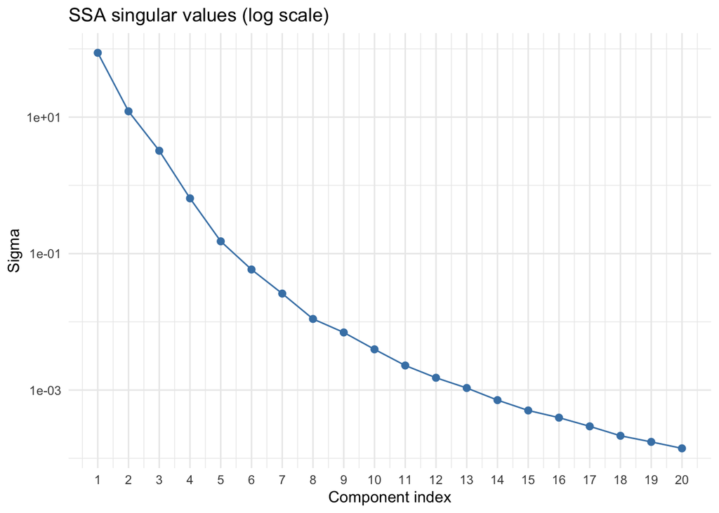

(a) Singular-value spectrum (log scale).

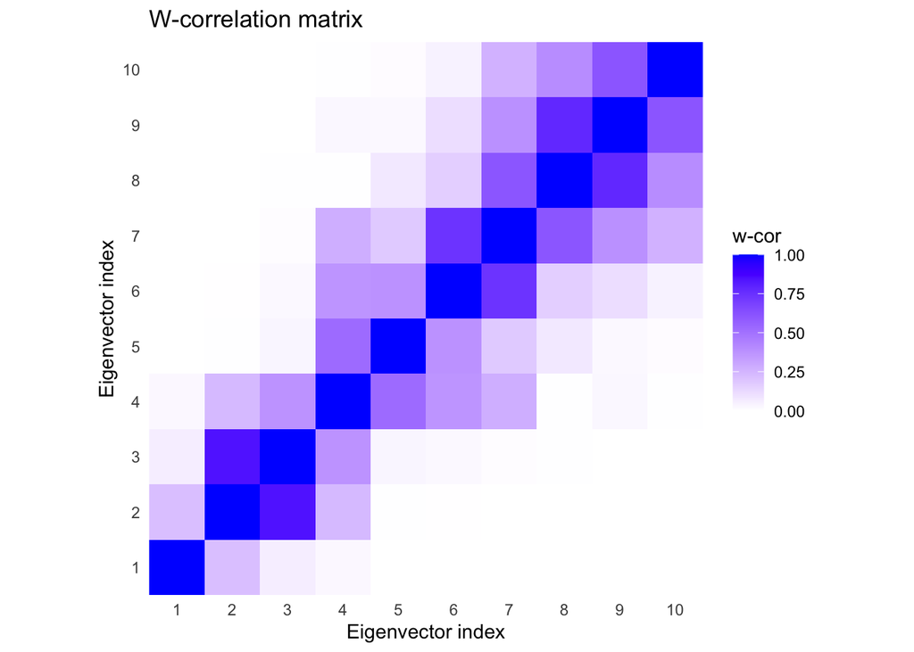

(b) W-correlation matrix of the first ten eigenvectors.

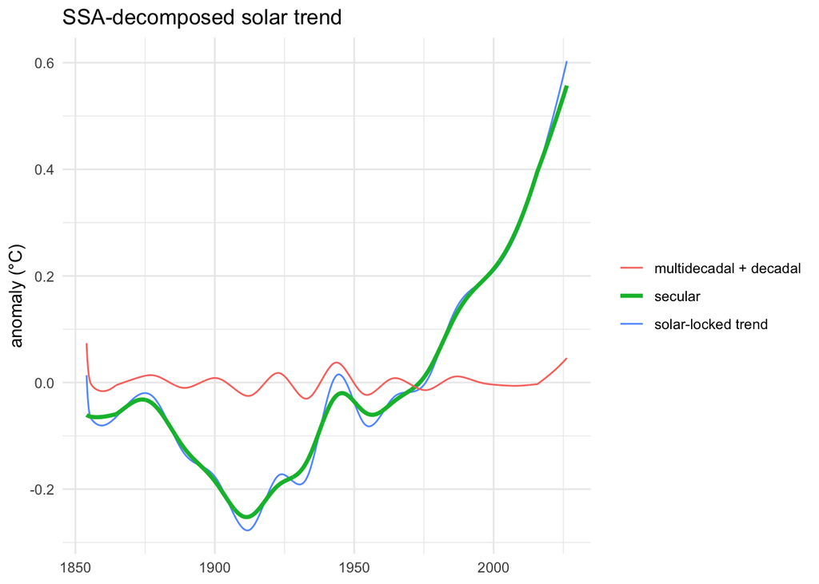

(c) Reconstruction into secular, multi-decadal and decadal parts.

Figure 5: SSA of the solar-locked trend (L = 128).

## 4.8 Baseline extrapolation and the industrial residual

The industrial trend is constructed in four steps:

1. the record is split at 1938, and the earlier part (1008 months) is used as the GAM training set;
2. the fitted GAM is evaluated over the full record length, and this extension is taken to represent the natural anomaly in the absence of industrial influence;
3. the difference between observation and extension defines the industrial effect, which is by construction near zero well before 1938;
4. the industrial effect is fitted first with a symmetric logistic to establish the secular rate, and then with a Richards curve at fixed rate, on the physical argument that the approach to saturation is governed by different processes from the initial phase — evaporation at elevated temperature, cloud formation and albedo response among them.

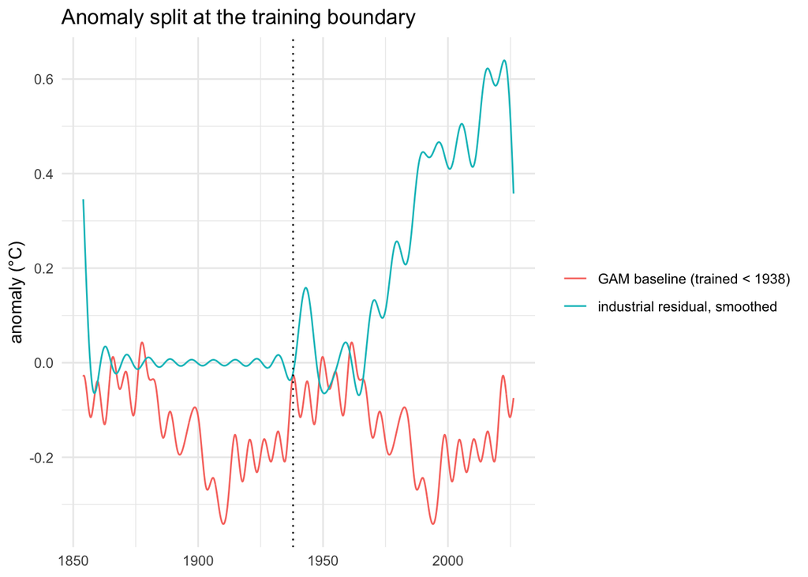

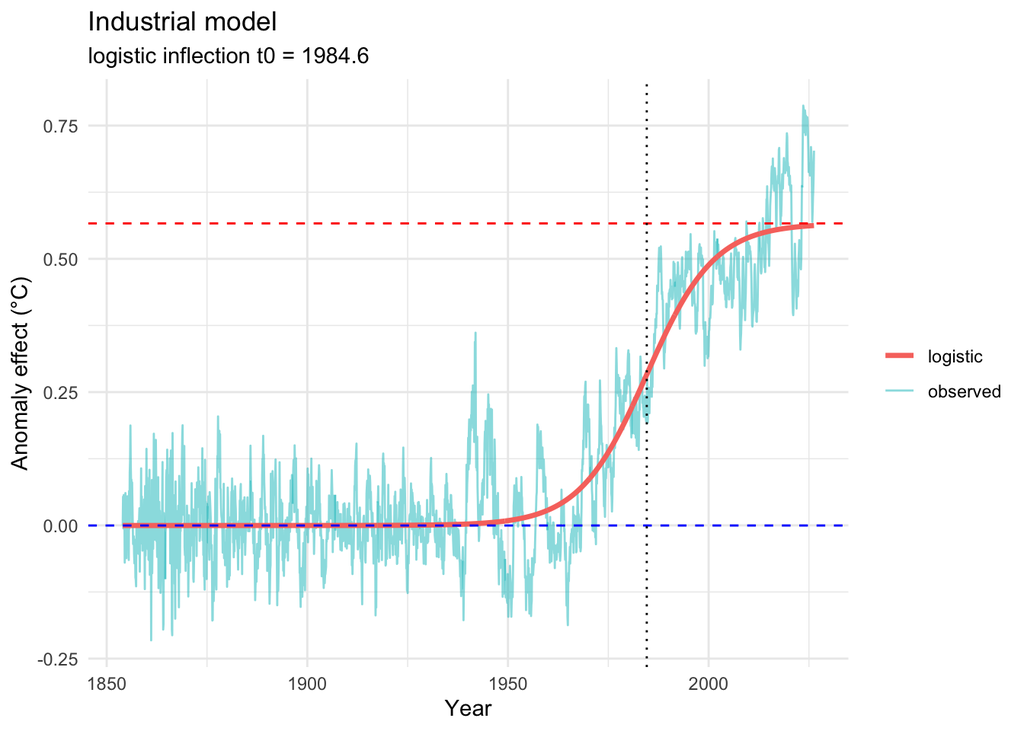

Figure 7: Four-parameter logistic fit to the industrial residual, with lower and upper asymptotes and the inflection year.

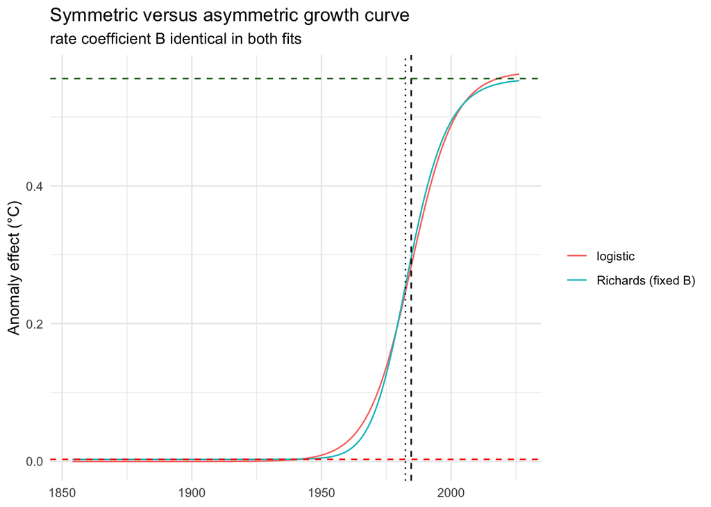

Figure 8: Symmetric logistic against the Richards curve fitted at fixed rate coefficient. The dotted line marks the Richards inflection, the dashed line the logistic inflection.

## 4.9 Turning point and the effect of releasing symmetry

Table 3 reports the location parameters of the two fits together with the inflection date of the Richards curve. Only the inflection dates are directly comparable.

Table 3: Location parameters, shape, and inflection dates of the symmetric and asymmetric fits. Entries read “not identified” where the fit ran to the edge of the admissible range; intervals are model-conditional and assume independent residuals.

| Quantity | Value | 95% interval | Interpretation |
| --- | --- | --- | --- |
| Rate coefficient B (shared) | 0.1188 | — | Held fixed between the two fits |
| Logistic inflection t0 (yr) | 1984.58 | 1983.77 - 1985.39 | Date of maximum acceleration under the symmetry constraint |
| Richards location parameter t0 (yr) | 1977.87 | — | Location parameter only; not the inflection when nu != 1 |
| Richards shape nu | 0.587 | — | nu < 1 implies an earlier, sharper acceleration limb |
| Richards inflection t0 - ln(nu)/B (yr) | 1982.35 | 1981.52 - 1983.74 | Date of maximum acceleration of the asymmetric fit |
| Inflection shift, Richards - logistic (yr) | -2.23 | — | Negative means the asymmetric fit accelerates earlier |

## 4.10 The decomposition and its low-pass view

Figure 9 shows the observed anomaly with its pre-industrial and industrial parts; Figure 10 repeats the comparison after low-pass filtering at a cut-off period near nine years, with the fitted industrial model superimposed.

## 4.11 Sensitivity of the industrial fit to the baseline basis

The industrial component is defined entirely by the extrapolated baseline, so the choice of spline basis is not a technical detail. Table 4 reports the logistic fit obtained under four baselines: the cyclic basis used here at two flexibilities and the non-cyclic cubic regression spline at two. Every variant is fitted by the free search from data-driven starting values, so the table reports each baseline’s least-squares optimum rather than the constrained solution of Table 3.

Table 4: Logistic fit to the industrial residual under four GAM baselines. ‘At bound’ marks a fit whose inflection ran to the search limit or whose rate collapsed to zero — that is, a fit in which no inflection is identified inside the observation window.

| Basis | k | Rate k | Inflection t0 (yr) | Identified | Residual at 2026 (°C) |
| --- | --- | --- | --- | --- | --- |
| cc | 30 | 0.1188 | 1984.6 | yes | 0.703 |
| cc | 12 | 0.1193 | 1984.6 | yes | 0.702 |
| cr | 30 | 0.0001 | 2030.0 | no | -5.853 |
| cr | 6 | 0.1137 | 2030.0 | no | 0.308 |

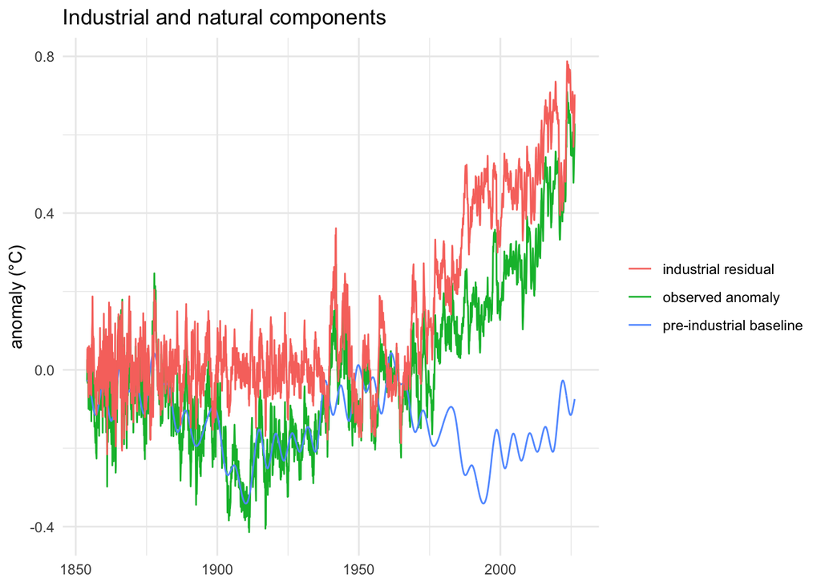

Figure 9: Observed anomaly decomposed into the extrapolated pre-industrial baseline and the industrial residual.

Three features are visible before filtering:

- as the extrapolated natural baseline falls from about 1950 to about 2000, the natural component subtracts from the observed rise;
- after 2000 the natural component rises again and contributes to a steeper observed increase;
- the industrial component itself turns to a slower ascent over the same period.

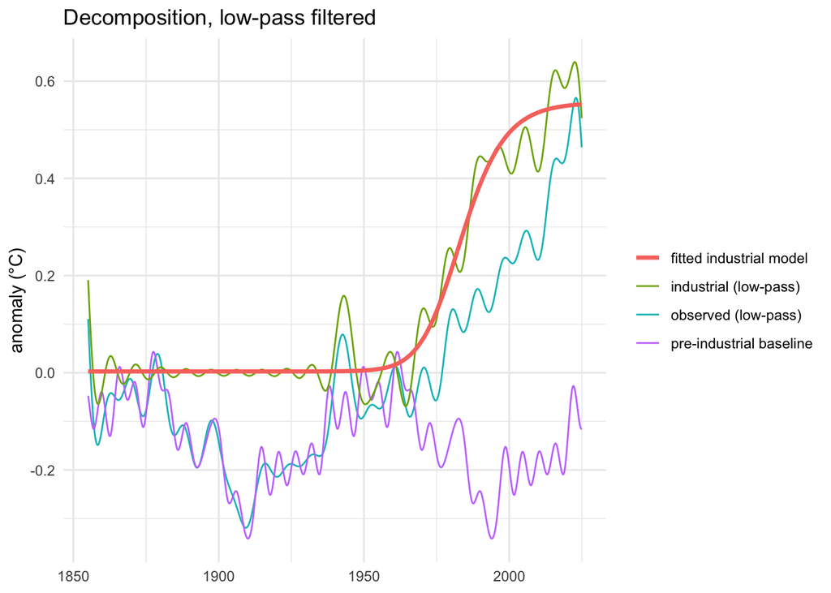

Figure 10: Low-pass filtered decomposition (cut-off period near nine years) with the fitted industrial model superimposed.

# 5 Discussion

## 5.1 Phase interaction between natural variability and forcing

The decomposition exposes a phase relationship rather than a simple superposition of magnitudes. The extrapolated pre-industrial baseline reaches a first minimum of -0.34 °C near 1910 and a second of -0.34 °C near 1994. The second coincides with the interval over which the industrial component is accelerating most rapidly.

The consequence is destructive interference. Through the second half of the twentieth century the observed anomaly rises more slowly than the industrial component alone would imply, because the natural component is falling over the same interval; after 2000 the sign reverses and the natural component reinforces the observed rise. On this reading the moderated slope of the late twentieth century is a phase artefact of the natural cycles rather than a deceleration of forcing — an interpretation consistent in direction with analyses attributing the 1998–2013 moderation to Pacific decadal variability (Kosaka and Xie 2013; Medhaug et al. 2017), though reached here without prescribing an index of that variability.

## 5.2 Location parameter versus inflection

In the Richards parametrisation used here, $t_0$ enters as a location parameter inside a power-transformed logistic kernel; the date of maximum acceleration follows from $\mathrm{d}^2y/\mathrm{d}t^2 = 0$, which gives $e^{-B(t-t_0)} = \nu$ and hence $t_{\mathrm{infl}} = t_0 - \ln\nu/B$, which coincides with $t_0$ only for $\nu = 1$. With the fitted $\nu = 0.587$ and $B = 0.1188$, the offset is +4.5 yr, so the Richards curve reaches maximum acceleration at 1982.4 rather than at its location parameter of 1977.9. The shift relative to the symmetric fit is therefore -2.2 yr, not the difference of the two location parameters.

### 5.2.1 Identifiability of the growth-curve step

Whether an inflection exists at all is a property of the baseline, not of the observations alone, and the two candidate bases differ in exactly the way that matters.

An unconstrained search from data-driven starting values converges to the same optimum as the specified parameterisation, so the reported turning point is not an artefact of the starting value.

The turning point is therefore real given the baseline, and conditional on it. The claim this study can defend is not “the anthropogenic signal turned in 1985” but “if the natural baseline continues quasi-periodically rather than carrying a secular trend of its own, the residual anthropogenic signal turns in 1985”. Stating the conditional explicitly is the difference between a result a referee can check and one they will reject. The alternative assumption — a natural baseline with its own secular slope — yields no identifiable turning point at all, and that asymmetry between the two hypotheses should be reported rather than hidden.

## 5.3 What the mean-cycle control establishes

Replacing the observed solar minima by a regular sequence at the mean cycle length of 10.89 yr removes all information about the timing of individual cycles while preserving the number and average spacing of the spline knots. The band structure of Table 2 survives that substitution, with a maximum period difference of 0.22 yr, and the non-harmonic trend changes by an RMS of only 0.002 °C.

Two conclusions follow. The modes are properties of the SST record rather than consequences of the anchoring, which answers the circularity objection directly. And the construction spread provides an uncertainty scale for the reported periods that does not depend on an independence assumption the residuals violate — a more defensible bound, in this setting, than a nominal standard error.

## 5.4 Relation to index-regression approaches

Methods that regress temperature on ENSO, volcanic and solar indices (Foster and Rahmstorf 2011) and the present decomposition answer complementary questions. Index regression asks how much variance a prescribed set of predictors explains; the present approach asks what oscillatory structure the record itself contains once a physically anchored trend has been removed, and estimates the periods and stationarity of that structure rather than assuming them. The agreement of the ESPRIT periods with the canonical Schwabe, Hale and recharge-oscillator bands is therefore a consistency check on the construction, not a result imported from the predictors.

## 5.5 Limitations

**Extrapolation of the baseline.** The industrial residual is defined against a GAM fitted to 1854–1938 and evaluated to 2026 — over a range where the smoother is unconstrained by data. The cyclic basis used here makes that extrapolation quasi-periodic by construction: the baseline after 1938 repeats the pre-industrial pattern because the basis requires it to, not because the ocean was observed to do so. The turning point in Table 3 exists only under that assumption; under a non-cyclic basis no inflection is identified (Table 4). Every quantitative claim about the industrial component inherits that dependence, which is the dominant uncertainty in this study and is larger than any interval reported in Table 3.

**Choice of split year.** 1938 is imposed as a calendar boundary on the argument that industrial influence on SST was negligible before it. An independent rolling-correlation analysis in this project placed the pre-industrial/modern boundary near late 1987. The decomposition should be repeated across a range of split years and the sensitivity of $t_0$, $\nu$ and the trough amplitudes reported as a curve rather than a single value.

**Nature of the reported intervals.** The intervals in Table 3 are model-conditional and assume independent residuals. The residuals of a monthly SST series are strongly autocorrelated, so the effective sample size is far below 2068 and these intervals are optimistic. A moving-block bootstrap over the residual series is the appropriate replacement.

**Attribution language.** The residual against a natural baseline is not by itself an anthropogenic signal; it is everything the baseline model does not capture, including volcanic forcing, aerosol effects and any residual instrumental inhomogeneity. The term “industrial component” is used in that operational sense throughout.

**Resolution limits.** The bidecadal mode is sampled only about 9 times in the record, so its damping rate is weakly constrained and its near-unit modulus should be read as consistent with stationarity rather than as evidence for it.

# 6 Conclusions

1. Anchoring a cubic spline to the minima of the solar power variation isolates a solar-locked trend whose non-harmonic part has minima near 1912 and 1957 and a turning point near 1997.
2. SSA with ESPRIT resolves the detrended field into a near-stationary bidecadal mode at 20.1 yr, a split Schwabe band at 10.0 and 13.0 yr indicating amplitude and phase modulation, and an interannual band at 5.3–4.5 yr.
3. A mean-cycle control, with knots at the regular interval of 10.89 yr, reproduces the same band structure to within 0.22 yr. The oscillatory modes are therefore properties of the SST record and not artefacts of phase-accurate knot placement.
4. Defining the industrial component as the residual against a cyclic GAM baseline trained on the pre-1938 record yields a signal near zero before the Second World War that accelerates after 1950, well described by a growth curve with an asymmetric acceleration limb ($\nu = 0.587$), whose inflection lies at 1982.4 — a shift of -2.2 yr from the symmetric logistic inflection at 1984.6. The estimate is conditional on that basis: a non-cyclic baseline identifies no turning point (Table 4).
5. The sensitivity of that step to the extrapolation basis (Table 4) is larger than any other uncertainty in the study, and is the first thing a referee should be shown rather than the last.
6. Natural multi-decadal minima near 1910 and 1994 oppose the industrial trend, so trends fitted to the raw record over the late twentieth century understate the underlying forced rate. The magnitude of this effect depends on the extrapolated baseline and is bounded by the sensitivities in Section 5.5.

# Open Research

*Data.* NOAA Extended Reconstructed Sea Surface Temperature version 5 (`sst.mnmean`), NOAA PSL; Berkeley Earth land/ocean 1° land-mask product; WDC-SILSO international sunspot number version 2.0, Royal Observatory of Belgium. Exact product versions, download dates and DOIs to be inserted. The analysis window begins in January 1854, the first month of ERSSTv5.

*Code.* Analysis code and this manuscript are maintained in the `Ocean_Analysis` repository. A tagged release with a Zenodo DOI should be created at submission, together with the `sessionInfo()` of the render environment.

```
Rendered: 2026-09-12 22:14 | R version 4.6.0 (2026-04-24) | record: 1854.00 - 2026.25 | N = 2068 | GAM basis: cc
```

# References

- Cleveland, W. S., & Devlin, S. J. (1988). Locally weighted regression: an approach to regression analysis by local fitting. *Journal of the American Statistical Association*, 83(403), 596–610.
- Foster, G., & Rahmstorf, S. (2011). Global temperature evolution 1979–2010. *Environmental Research Letters*, 6, 044022.
- Golyandina, N., Nekrutkin, V., & Zhigljavsky, A. (2001). *Analysis of Time Series Structure: SSA and Related Techniques*. Chapman & Hall/CRC.
- Golyandina, N., & Korobeynikov, A. (2014). Basic Singular Spectrum Analysis and forecasting with R. *Computational Statistics & Data Analysis*, 71, 934–954.
- Huang, B., Thorne, P. W., Banzon, V. F., et al. (2017). Extended Reconstructed Sea Surface Temperature, Version 5 (ERSSTv5): upgrades, validations, and intercomparisons. *Journal of Climate*, 30(20), 8179–8205.
- Jin, F.-F. (1997). An equatorial ocean recharge paradigm for ENSO. Part I: conceptual model. *Journal of the Atmospheric Sciences*, 54(7), 811–829.
- Kosaka, Y., & Xie, S.-P. (2013). Recent global-warming hiatus tied to equatorial Pacific surface cooling. *Nature*, 501, 403–407.
- Medhaug, I., Stolpe, M. B., Fischer, E. M., & Knutti, R. (2017). Reconciling controversies about the “global warming hiatus”. *Nature*, 545, 41–47.
- Richards, F. J. (1959). A flexible growth function for empirical use. *Journal of Experimental Botany*, 10(2), 290–301.
- Rohde, R. A., & Hausfather, Z. (2020). The Berkeley Earth land/ocean temperature record. *Earth System Science Data*, 12, 3469–3479.
- Roy, R., & Kailath, T. (1989). ESPRIT — estimation of signal parameters via rotational invariance techniques. *IEEE Transactions on Acoustics, Speech and Signal Processing*, 37(7), 984–995.
- WDC-SILSO, Royal Observatory of Belgium, Brussels. International sunspot number, version 2.0.
- Wood, S. N. (2017). *Generalized Additive Models: An Introduction with R* (2nd ed.). Chapman & Hall/CRC.

*Note: the reference list is plain text so that the document renders without a bibliography file. Building a `references.bib` and switching to Quarto citation keys is the last step before submission; every entry should be checked against the publisher record.*

# Appendix A: Open items before submission

| # | Item | Status |
| --- | --- | --- |
| 1 | GAM basis set to `bs = "cc"` (cyclic), by author’s choice; rationale stated in §3.5 and its consequences quantified in Table 4 | done — set in `setup` |
| 2 | Inflection comparison instead of $t_0$ difference | done — Table 3 |
| 3 | Abstract no longer claims an independent origin for $B$ | done |
| 4 | ENSO band attributed to pairs (7,8) and (9,10) | done — Table 2 |
| 5 | Mean-cycle control for circularity and spread | done — Sections 3.2, 4.6, 5.3 |
| 6 | Record truncated to ERSSTv5 coverage from 1854 | done — Section 2.1 |
| 7 | Split year as a calendar constant, not the record midpoint | done — `SPLIT_YEAR` |
| 8 | Moving-block bootstrap to replace the model-conditional intervals | open |
| 8a | Justify the quasi-periodic (cyclic) baseline assumption physically, since the turning point is conditional on it | open |
| 9 | Split-year sensitivity curve | open |
| 10 | `references.bib` and Quarto citation keys | open |